# HAR Final Assessment

Practical Machine Learning Project

Mathias Barat

## 1 - SYNOPSIS

### Context

Using devices such as Jawbone Up, Nike FuelBand, and Fitbit it is now possible to collect a large amount of data about personal activity relatively inexpensively.

These type of devices are part of the quantified self movement – a group of enthusiasts who take measurements about themselves regularly to improve their health, to find patterns in their behavior, or because they are tech geeks.

### Problem

One thing that people regularly do is quantify how much of a particular activity they do, but they rarely quantify how well they do it.

### Goal of the project

Use data from accelerometers on the belt, forearm, arm, and dumbell of 6 participants. They were asked to perform barbell lifts correctly and incorrectly in 5 different ways.

More information is available from the website here: http://groupware.les.inf.puc-rio.br/har (see the section on the Weight Lifting Exercise Dataset).

### Dataset information

Velloso, E.; Bulling, A.; Gellersen, H.; Ugulino, W.; Fuks, H. Qualitative Activity Recognition of Weight Lifting Exercises. Proceedings of 4th International Conference in Cooperation with SIGCHI (Augmented Human ’13) . Stuttgart, Germany: ACM SIGCHI, 2013.

Read more: http://groupware.les.inf.puc-rio.br/har#ixzz6ZuaJcLo0

## 2 - DATASETS

### Downloading file:

```r
train_url <- "https://d396qusza40orc.cloudfront.net/predmachlearn/pml-training.csv"
test_url <- "https://d396qusza40orc.cloudfront.net/predmachlearn/pml-testing.csv"
if (!file.exists("data/training.csv") | !file.exists("data/testing.csv")){
  download.file(train_url, destfile = "data/training.csv")
  download.file(test_url, destfile = "data/testing.csv")
}

training <- read.csv("data/training.csv", na.strings=c("NA","#DIV/0!", ""))
testing <- read.csv("data/testing.csv",na.strings=c("NA","#DIV/0!", ""))
```

### Exploratory Data Analysis

```r
summary(training$classe)
```

```
##    Length     Class      Mode
##     19622 character character
```

```r
unique(training$classe)
```

```
## [1] "A" "B" "C" "D" "E"
```

```r
training$classe <- factor(training$classe)
```

### Cleaning

Suppress all NA in the dataset

```r
training <- training[,colSums(is.na(training)) == 0]
testing <- testing[,colSums(is.na(training)) == 0]
```

### Suppress useless columns

```r
# X, user_name, timestamps, windows
training <- training[,-c(1:7)]
testing <- testing[,-c(1:7)]
```

### testing, training and quizz datasets

To avoid errors I rename the datasets and create my own training, testing dataset

```r
library(caret)
test_quizz <- testing
inTrain <- createDataPartition(training$classe, p = 0.8, list = FALSE)
temp <- training
training <- temp[inTrain,]
testing <- temp[-inTrain,]
rm(temp)
```

### final dataset

```r
# Training dataset:
dim(training)
```

```
## [1] 15699    53
```

```r
# Testing dataset:
dim(testing)
```

```
## [1] 3923   53
```

```r
# Testing dataset
dim(test_quizz)
```

```
## [1]  20 153
```

### Histogram of Y

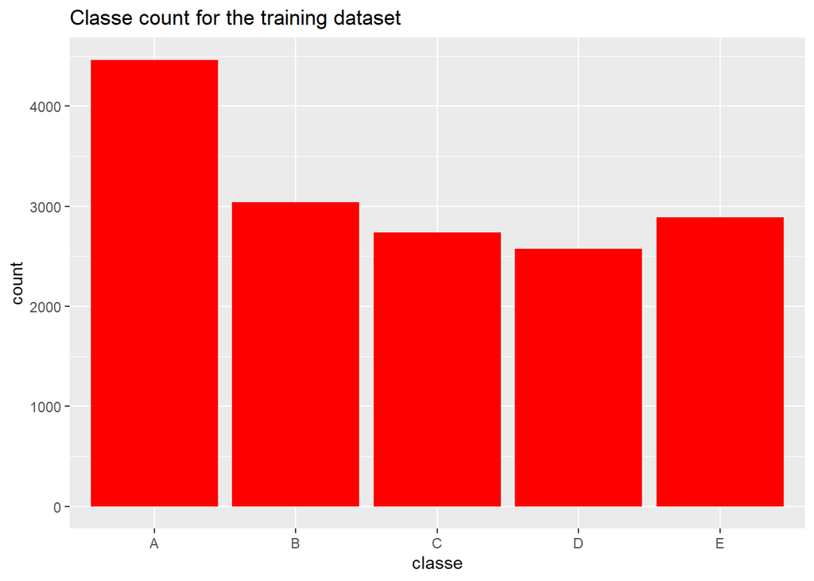

```r
library(ggplot2)
ggplot(training, aes(x=classe)) + geom_histogram(stat = "count", fill="red")+ labs(title="Classe count for the training dataset")
```

## 3 - Recursive Partition modeling

```r
library(ggplot2); library(caret); library(randomForest); library(rpart)

modfit_rpart <- rpart(classe ~ ., data=training, method="class")

predict_rpart <- predict(modfit_rpart, testing, type = "class")
```

```r
library(rattle)
```

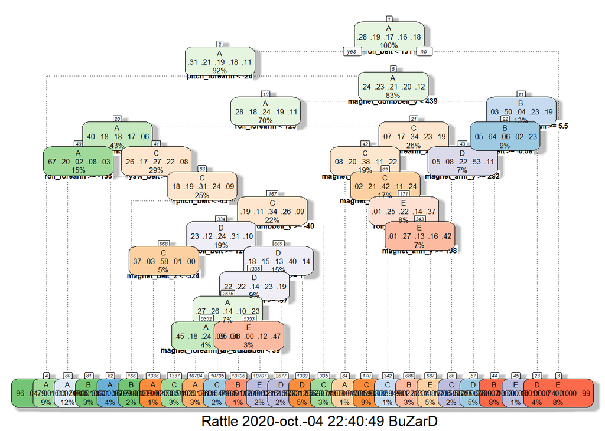

```r
fancyRpartPlot(modfit_rpart, cex= 0.5)
```

```r
confusionMatrix(predict_rpart, testing$classe)
```

```
## Confusion Matrix and Statistics
##
##           Reference
## Prediction   A   B   C   D   E
##          A 990 163  19  35   6
##          B  28 409  48  66  72
##          C  30 106 552  53  49
##          D  53  49  54 421  53
##          E  15  32  11  68 541
##
## Overall Statistics
##
##                Accuracy : 0.7425
##                  95% CI : (0.7286, 0.7562)
##     No Information Rate : 0.2845
##     P-Value [Acc > NIR] : < 2.2e-16
##
##                   Kappa : 0.6735
##
##  Mcnemar's Test P-Value : < 2.2e-16
##
## Statistics by Class:
##
##                      Class: A Class: B Class: C Class: D Class: E
## Sensitivity            0.8871   0.5389   0.8070   0.6547   0.7503
## Specificity            0.9206   0.9324   0.9265   0.9363   0.9606
## Pos Pred Value         0.8162   0.6565   0.6987   0.6683   0.8111
## Neg Pred Value         0.9535   0.8939   0.9579   0.9326   0.9447
## Prevalence             0.2845   0.1935   0.1744   0.1639   0.1838
## Detection Rate         0.2524   0.1043   0.1407   0.1073   0.1379
## Detection Prevalence   0.3092   0.1588   0.2014   0.1606   0.1700
## Balanced Accuracy      0.9038   0.7356   0.8668   0.7955   0.8555
```

## 4 - Random Forest Modeling

```r
library(randomForest)
modfit_rforest <- randomForest(classe ~ .,data=training, method = "class", keep.inbag = TRUE)
predict_rforest <- predict(modfit_rforest, testing, type = "class")

modfit_rforest
```

```
##
## Call:
##  randomForest(formula = classe ~ ., data = training, method = "class",      keep.inbag = TRUE)
##                Type of random forest: classification
##                      Number of trees: 500
## No. of variables tried at each split: 7
##
##         OOB estimate of  error rate: 0.42%
## Confusion matrix:
##      A    B    C    D    E  class.error
## A 4463    1    0    0    0 0.0002240143
## B   12 3020    6    0    0 0.0059249506
## C    0   14 2724    0    0 0.0051132213
## D    0    0   20 2551    2 0.0085503304
## E    0    0    3    8 2875 0.0038115038
```

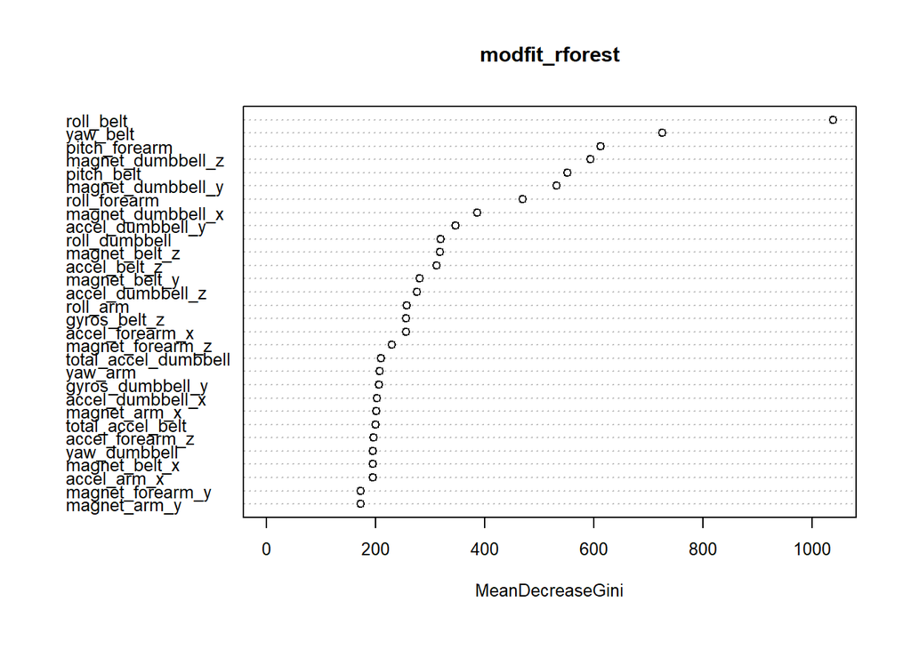

```r
varImpPlot(modfit_rforest, cex = 0.8 )
```

```r
confusionMatrix(predict_rforest, testing$classe)
```

```
## Confusion Matrix and Statistics
##
##           Reference
## Prediction    A    B    C    D    E
##          A 1116    3    0    0    0
##          B    0  756    2    0    0
##          C    0    0  681    2    0
##          D    0    0    1  641    0
##          E    0    0    0    0  721
##
## Overall Statistics
##
##                Accuracy : 0.998
##                  95% CI : (0.996, 0.9991)
##     No Information Rate : 0.2845
##     P-Value [Acc > NIR] : < 2.2e-16
##
##                   Kappa : 0.9974
##
##  Mcnemar's Test P-Value : NA
##
## Statistics by Class:
##
##                      Class: A Class: B Class: C Class: D Class: E
## Sensitivity            1.0000   0.9960   0.9956   0.9969   1.0000
## Specificity            0.9989   0.9994   0.9994   0.9997   1.0000
## Pos Pred Value         0.9973   0.9974   0.9971   0.9984   1.0000
## Neg Pred Value         1.0000   0.9991   0.9991   0.9994   1.0000
## Prevalence             0.2845   0.1935   0.1744   0.1639   0.1838
## Detection Rate         0.2845   0.1927   0.1736   0.1634   0.1838
## Detection Prevalence   0.2852   0.1932   0.1741   0.1637   0.1838
## Balanced Accuracy      0.9995   0.9977   0.9975   0.9983   1.0000
```

## 5 - Conclusion

### Quizz prediction with the test set

```r
predict_quizz <- predict(modfit_rforest, test_quizz, type = "class")
predict_quizz
```

```
##  1  2  3  4  5  6  7  8  9 10 11 12 13 14 15 16 17 18 19 20
##  B  A  B  A  A  E  D  B  A  A  B  C  B  A  E  E  A  B  B  B
## Levels: A B C D E
```